# ggplot2

[figure not shown]

So far, we’ve only used `base graphics` plotting routines. While there are endless customizations and schemes that can be used to generate publiation quality material, many advanced R programmers use `ggplot2` to create plots. `ggplot2` is a go-to plotting package and can do all that `base graphics` can do with different styling. `ggplot2` is designed to work with `dataframes`, rather than individual `vectors`. `ggplot2` also has more aesthetic options that allow for more visually unique & pleasing plots. The first thing you’ll notice about `ggplot2` is that the syntax is different. Instead of coding all customizations through arguments or additional functions with the `add=TRUE` option keyed in, `ggplot2` uses `+` to add in extra layers to a plot. This may seem weird at first, but the longer you spend with it the more regular it will seem.

```r
library(ggplot2)
# load in a dataset - https://github.com/jsimkins2/geog473-673/blob/master/datasets/acadia.csv
acadia = read.csv("/Users/james/Documents/Github/geog473-673/datasets/acadia.csv")
# list the top rows of acadia
head(acadia)
```

```
##   X region state code            park_name          type visitors year
## 1 1     NE    ME ACAD Acadia National Park National Park    64000 1919
## 2 2     NE    ME ACAD Acadia National Park National Park    66500 1920
## 3 3     NE    ME ACAD Acadia National Park National Park    69836 1921
## 4 4     NE    ME ACAD Acadia National Park National Park    73779 1922
## 5 5     NE    ME ACAD Acadia National Park National Park    64200 1923
## 6 6     NE    ME ACAD Acadia National Park National Park    71758 1924
```

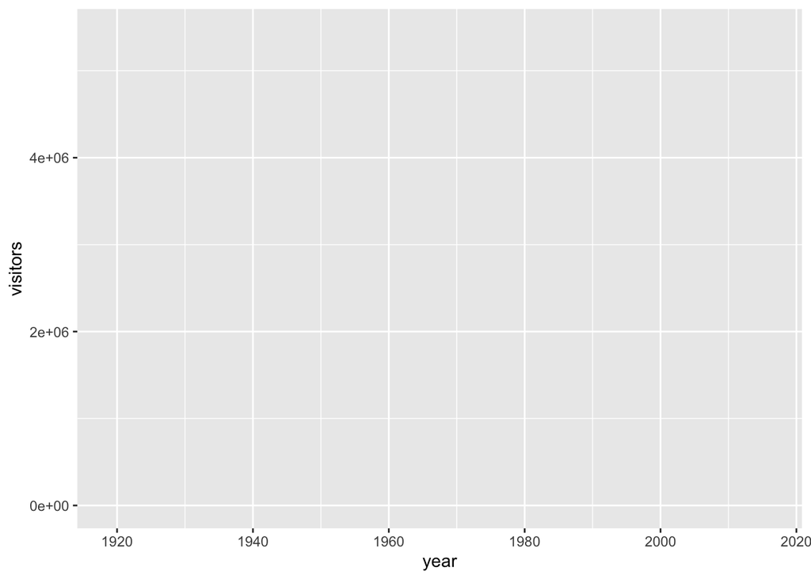

```r
# remove the X column, it's just a duplicate index
acadia$X = NULL
# Initialize Ggplot
ggplot(acadia, aes(x=year, y=visitors))  # year and visitors are columns in acadia dataframe, aes() stands for aesthetics
```

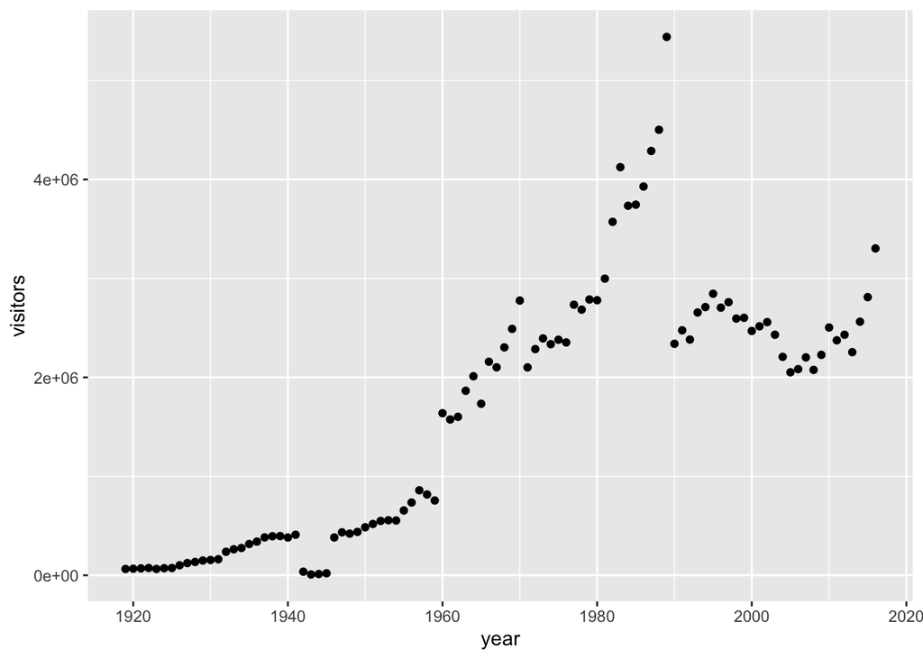

```r
# simple scatter plot
ggplot(acadia, aes(x=year, y=visitors)) + geom_point()
```

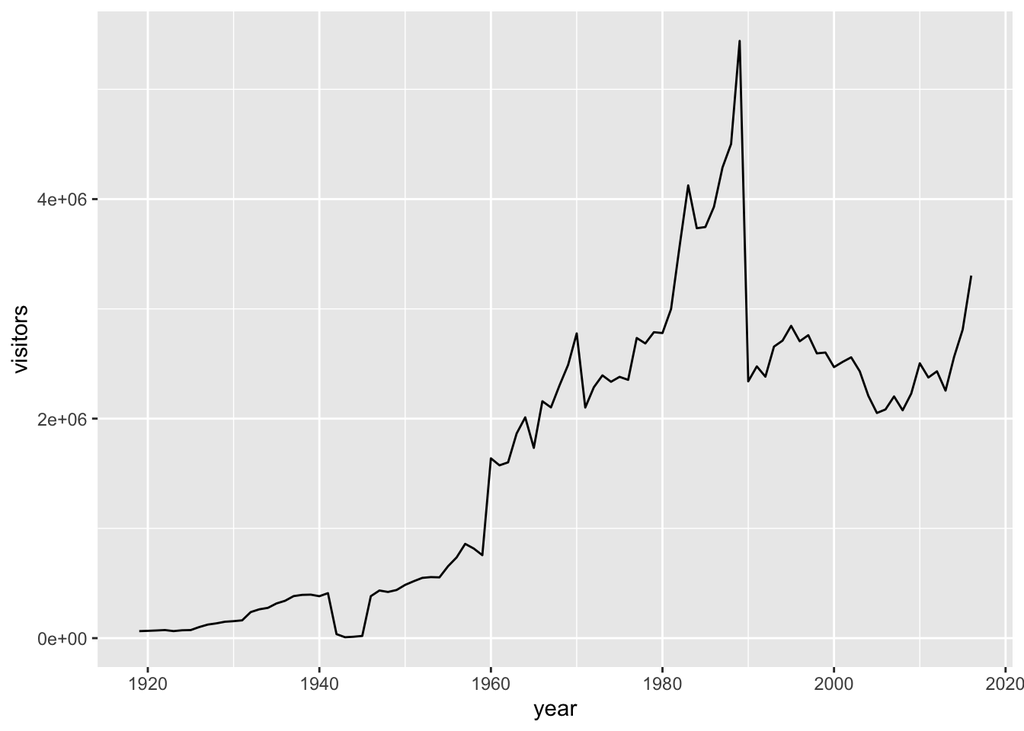

```r
# simple line plot
ggplot(acadia, aes(x=year, y=visitors)) + geom_line()
```

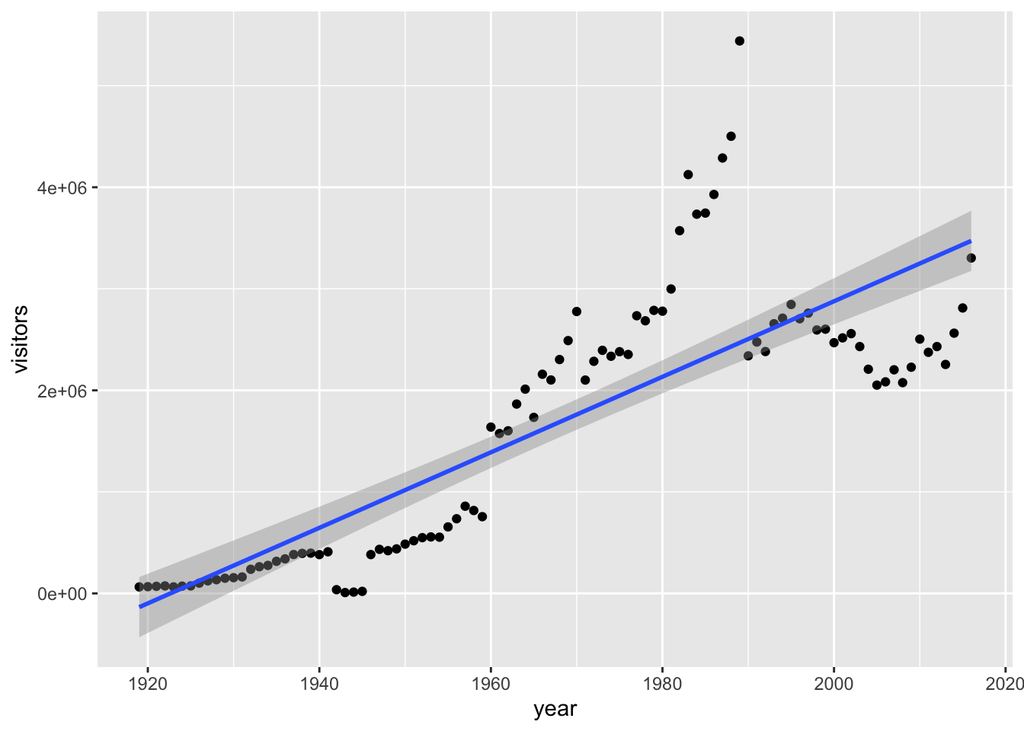

```r
# remember the trendline? here is how easy it is to add with ggplot2
ggplot(acadia, aes(x=year, y=visitors)) + geom_point() + geom_smooth(method="lm")
```

Notice above how `ggplot()` creates a ggplot plot, but the `geom_point()` or `geom_line()` add the data to the plot. This is a key difference between `base graphics` and `ggplot2`. Also notice how you add what you want to the plot via the `+` symbol. Since the `aes()` (aesthetics) axes are already defined and since the `acadia` dataframe has been set, the functions `geom_point()` and `geom_line()` already know what data to add to the plots based on the dataset, x and y axes.

Another cool thing about ggplot2() is that we can save a plot as an object and accumuatively add things to it

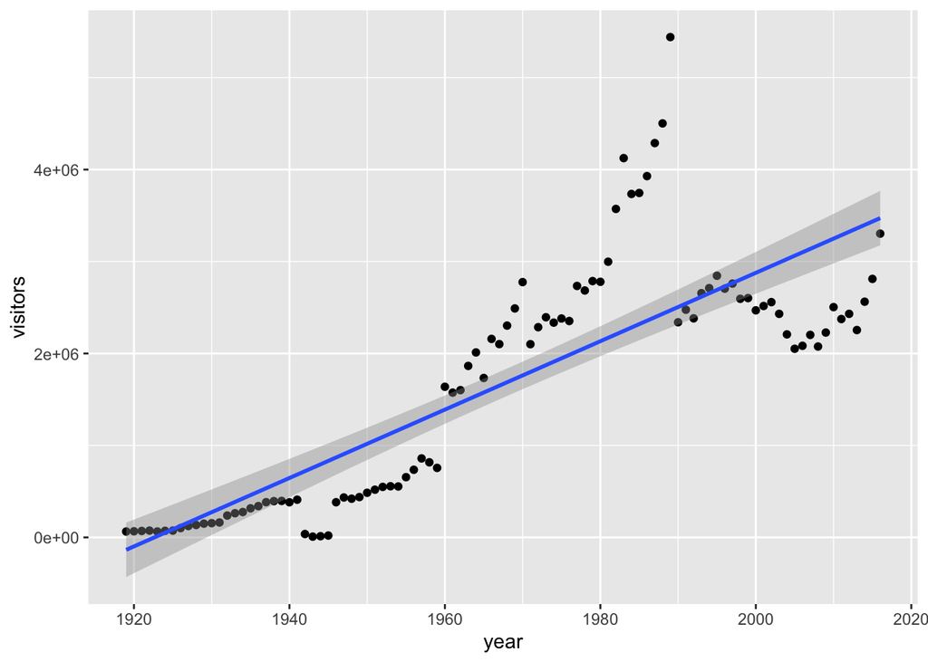

```r
g = ggplot(acadia, aes(x=year, y=visitors)) + geom_point() + geom_smooth(method="lm")
plot(g)
```

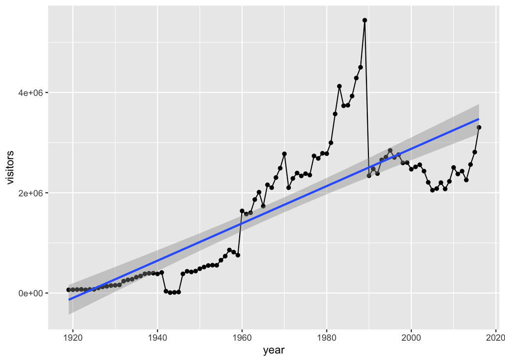

```r
# technically, we don't even have to say plot(g)...we can just print it and it will plot!
g = ggplot(acadia, aes(x=year, y=visitors))
g = g + geom_point()
g = g + geom_line()
g = g + geom_smooth(method="lm")
g
```

If you place `aes` in the initial `ggplot` argument, that sets the aesthetics, and the dataframe, for the entire plot regardless of the layers you add to it. However, we can also place an `aes` argument for *each* ggplot function we use (`geom_line`, `geom_point`, `geom_smooth`, etc.). **This is useful if we are working with multiple datasets**. Let’s create a dummy dataset with half the visitors of the `acadia` dataset and place the aesthetic function (`aes`) in each `geom_point` function.

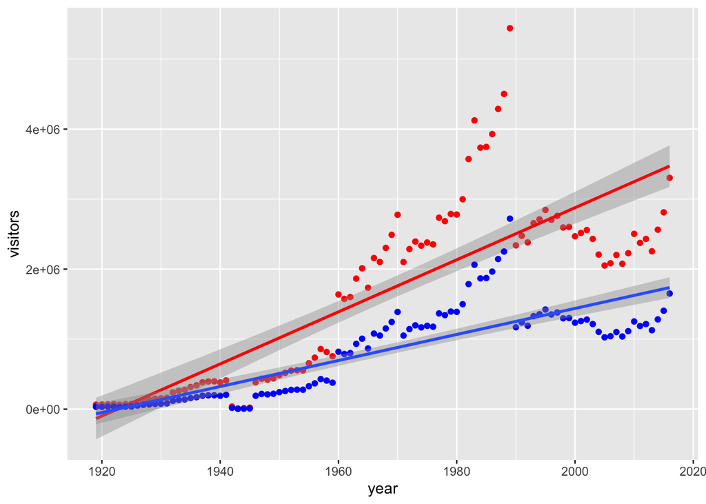

```r
# create dummy data where we divide the actual number of visitors by 2
dummy_data = acadia
dummy_data$visitors = dummy_data$visitors/2
# plot a ggplot instance with multiple lines
g = ggplot(acadia) + geom_point(aes(x=year, y=visitors), color="red") + geom_smooth(data = acadia, aes(x=year, y=visitors), method="lm", color="red") + geom_point(data = dummy_data,aes(x=year, y=visitors), color="blue") + geom_smooth(data = dummy_data, aes(x=year, y=visitors), method="lm")
plot(g)
```

We can “crop” out areas of a plot using `xlim` and `ylim`. This method does delete points, however.

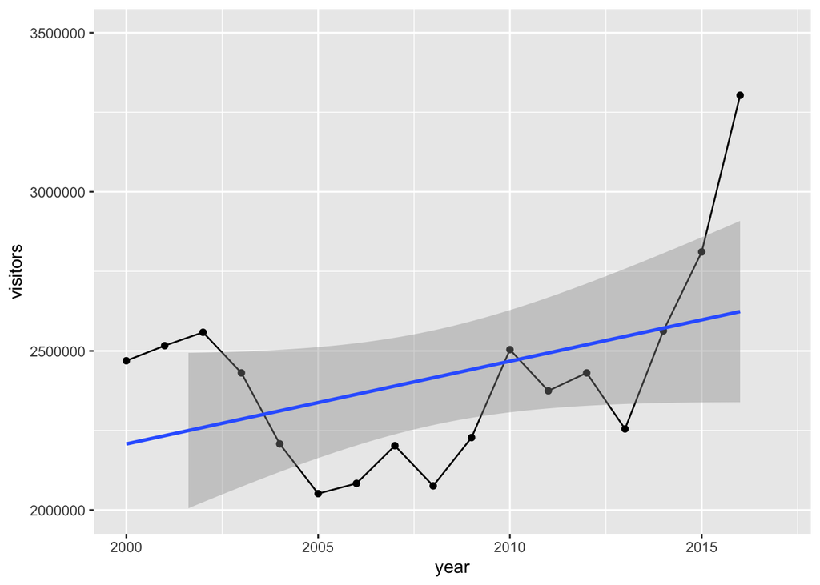

```r
g = ggplot(acadia, aes(x=year, y=visitors)) + geom_point() + geom_line() + geom_smooth(method="lm")
g + xlim(c(2000,2017)) + ylim(c(2000000, 3500000))  # x axis years 2000 to 2017, ylimit 2000000 to 3500000
```

Instead of cropping out, we can also just zoom in with the `coord_cartesian` function (we’re using cartesian coordinates here). This method **does not delete points**.

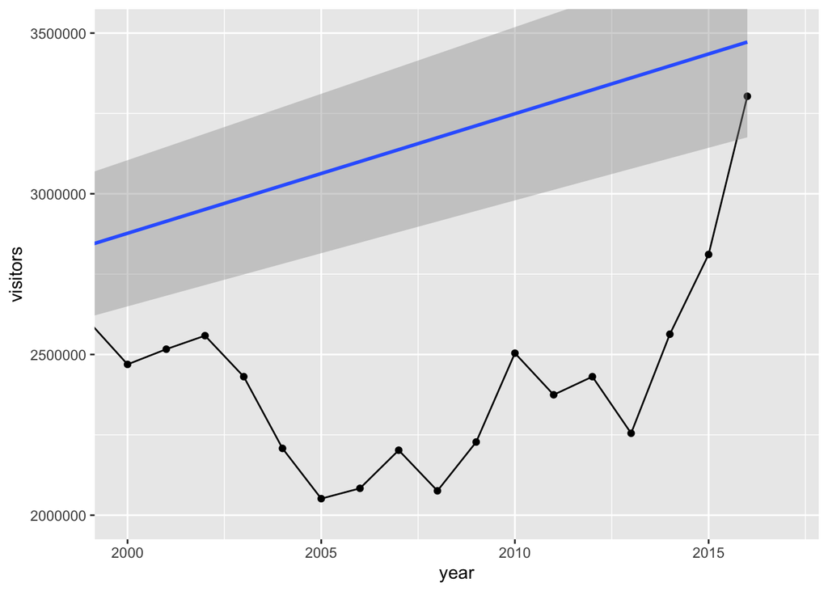

```r
g = ggplot(acadia, aes(x=year, y=visitors)) + geom_point() + geom_line() + geom_smooth(method="lm")
g + coord_cartesian(xlim=c(2000,2017), ylim = c(2000000, 3500000))  # x axis years 2000 to 2017, ylimit 2000000 to 3500000
```

Notice how different the trendline is above. When we just zoom in, we preserve all of the data going into the plot which helps us keep the trendline of the entire dataset.

Now let’s check out adjusting the x/y labels and title. There are 2 ways.

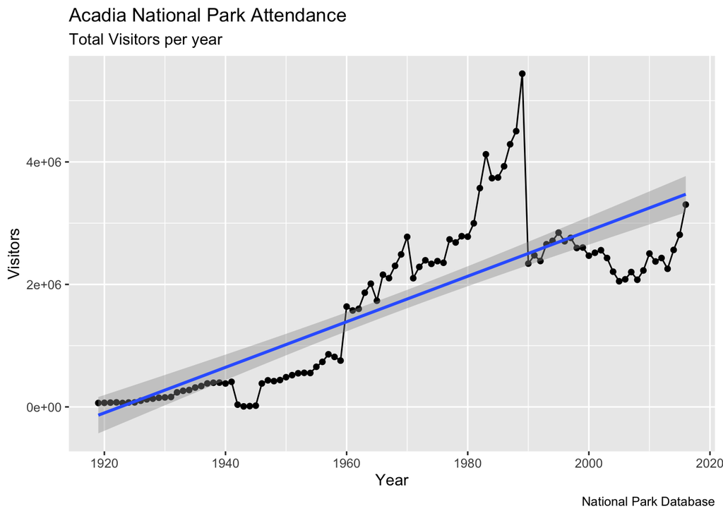

```r
# Add Title and Labels
g1 = ggplot(acadia, aes(x=year, y=visitors)) + geom_point() + geom_line() + geom_smooth(method="lm")
g1 + labs(title="Acadia National Park Attendance", subtitle="Total Visitors per year", y="Visitors", x="Year", caption="National Park Database")
```

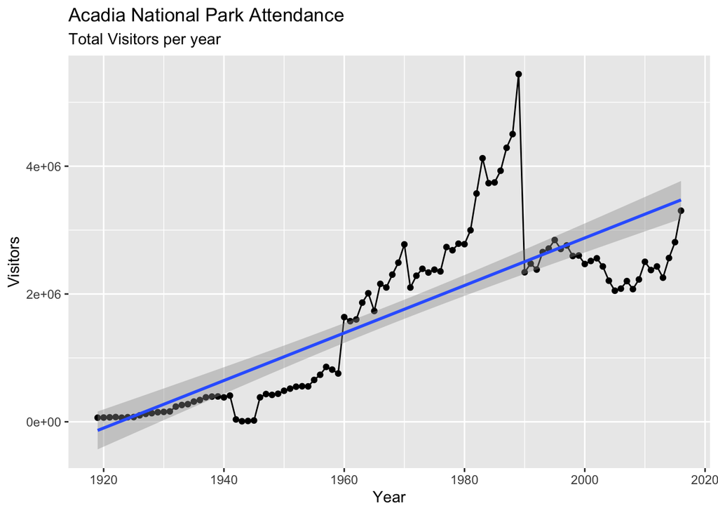

```r
# or
g2 = ggplot(acadia, aes(x=year, y=visitors)) + geom_point() + geom_line() + geom_smooth(method="lm")
g2 = g2 + ggtitle("Acadia National Park Attendance", subtitle="Total Visitors per year")
g2 + xlab("Year") + ylab("Visitors")
```

What about changing up the colors, size, etc.?

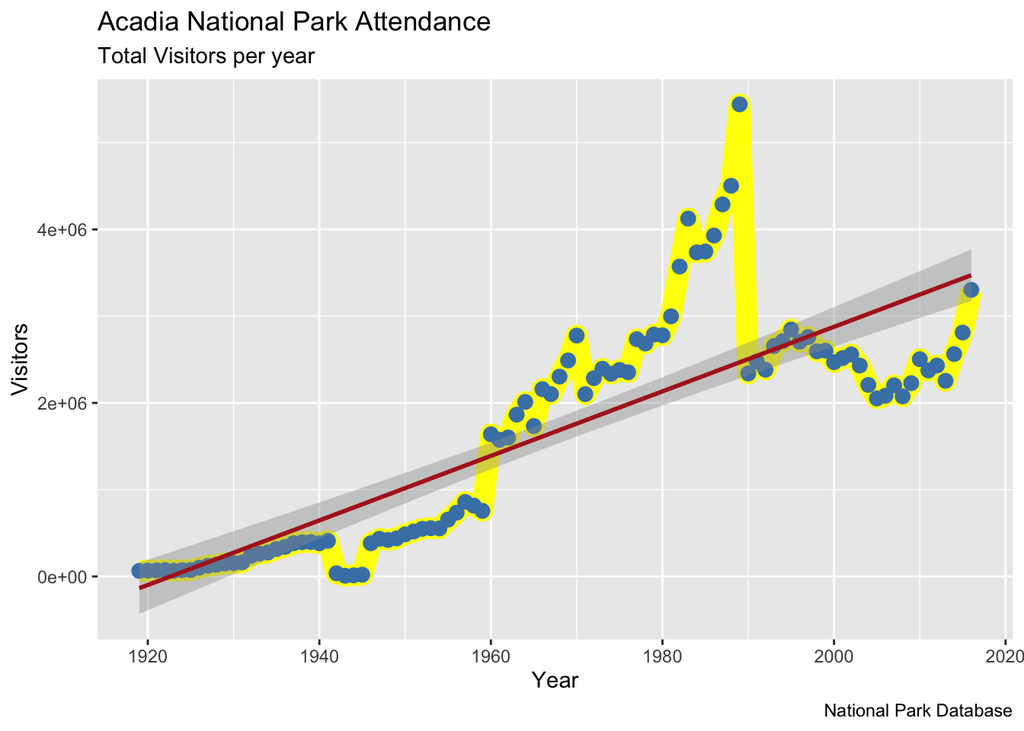

```r
g = ggplot(acadia, aes(x=year, y=visitors)) +
    geom_line(col="yellow", size=5) +
    geom_point(col="steelblue", size=3) +
    geom_smooth(method="lm", col="firebrick") +
    labs(title="Acadia National Park Attendance", subtitle="Total Visitors per year", y="Visitors", x="Year", caption="National Park Database")

g
```

## ggplot2 with Willow Creek Meteorological Data

Let’s use `ggplot2` to with the Willow Creek 2010 dataset.

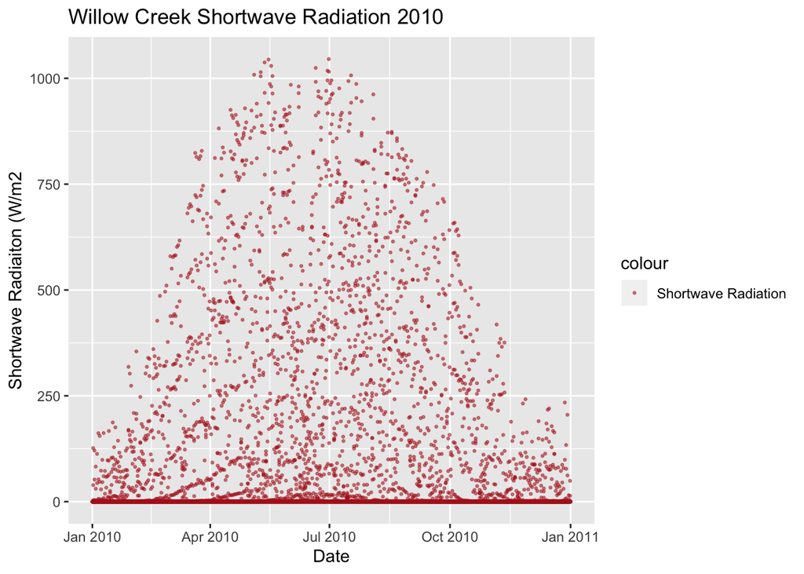

```r
library(ncdf4)
y = 2010
nc_file = nc_open(paste0("/Users/james/Documents/Github/geog473-673/datasets/WCr_1hr.", y,".nc"))
# what does the nc file look like
var_names = names(nc_file$var)
wcr_data = list()
dim <- nc_file$dim
for (v in seq_along(var_names)){
  wcr_data[[v]] = ncvar_get(nc_file, varid = var_names[v])
}
wcreek_df = data.frame(wcr_data)
colnames(wcreek_df) = var_names
# create a new short_names vector that matches the order of the actual names
short_names = c("tair", "tmax", "tmin", "lwave", "pres", "swave", "ewind", "nwind", "shum", "prec")
# rename the column names to our new short name vector
colnames(wcreek_df) = short_names
date.seq = seq(as.POSIXct(paste0(y,"-01-01 00:00:00")), as.POSIXct(paste0(y,"-12-31 23:00:00")), by="hour")
wcreek_df['datetime'] = date.seq

# Plot a ggplot point plot of willow creek 2010 shortwave radiation
ggplot(wcreek_df) +
  geom_point(data = wcreek_df, aes(y=swave, x=datetime, color = 'Shortwave Radiation'), size=0.5, alpha = 0.5) +
  xlab("Date") +
  ylab("Shortwave Radiaiton (W/m2") +
  ggtitle("Willow Creek Shortwave Radiation 2010") +
  scale_color_manual(values = c('Shortwave Radiation' = 'firebrick'))
```

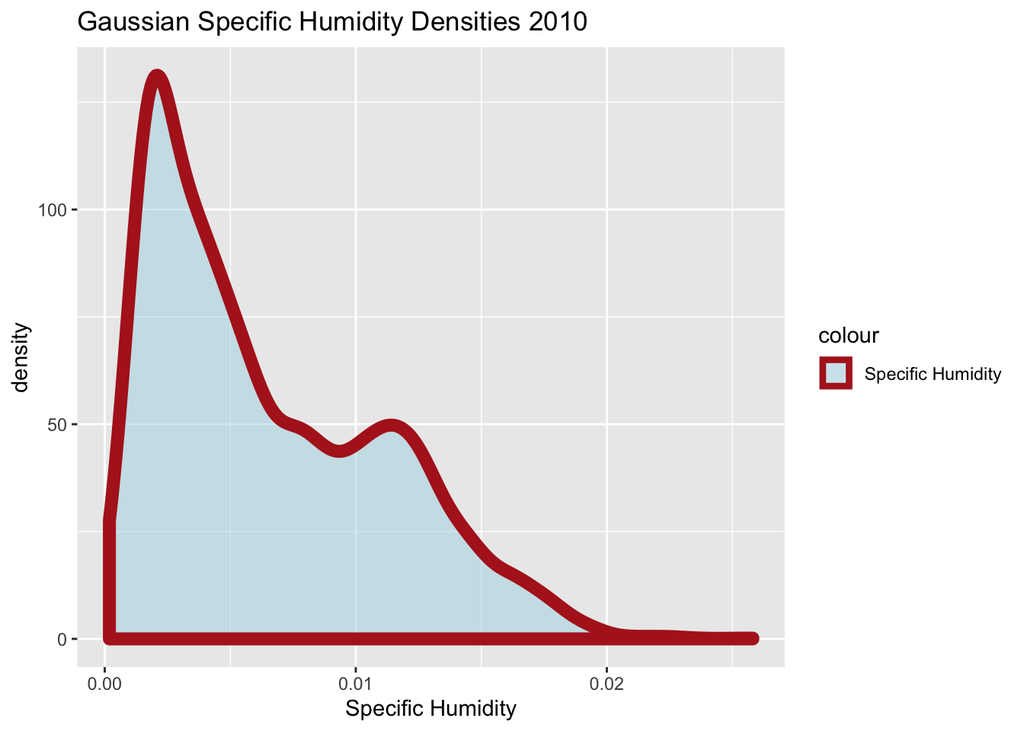

```r
# plot a ggplot density plot of the specific humidity
ggplot(wcreek_df) +
  geom_density(data = wcreek_df, aes(x=shum, y=..density.., color = 'Specific Humidity'), size=3, adjust = 1, fill="lightblue", alpha = 0.5) +
  xlab("Specific Humidity") +
  ggtitle("Gaussian Specific Humidity Densities 2010") +
  scale_color_manual(values = c('Specific Humidity' = 'firebrick'))
```

Let’s break down the `geom_density` plot above. First, we create a `ggplot` *window* of `wcreek_df` dataframe. Then, we call the the `geom_density` function and declared `data` argument as `wcreek_df`. Then, we specified the `aes` (aesthetics) function within the `geom_density` function. In the `aes`, we declared the x axis - `specific humidity` - and the y axis - `..density..` - which is necessary for the plot to know that’s the axis to place the density on. The final piece to the `aes()` argument is the color. Notice that we also set the color here to “Specific Humidity”. This is not a color in R. Rather, it’s a reference to the color we declare down below with `scale_color_manual`. In other words, we state below that the color of “Specific Humidity” is firebrick within the `scale_color_manual` function. Still within the `geom_density` function, we set the `size` of the `density` line, set the `adjust` which is ggplots term for bandwidth, declared a fill color to `fill` in the density area and gave that fill color an `alpha` of 0.5 to make it semi-transparent. Xlabel and title we’ve already covered. Finally I set a manual color label and shape of the label for specific humidity.

## Assignment:

Using the `WCr_1hr.2012.nc` found in the datasets folder, complete the following:

1. Using `ggplot2`, create an `geom_line` plot for `air_temperature`. Add a trendline to this plot. Include appropriate titles, axes, labels, colors, etc.
2. Using `ggplot2`, create a density plot of `air temperature` with appropriate titles, axes, legend etc.
3. Submit the plots to UD canvas.

Your final plots should look something like these…

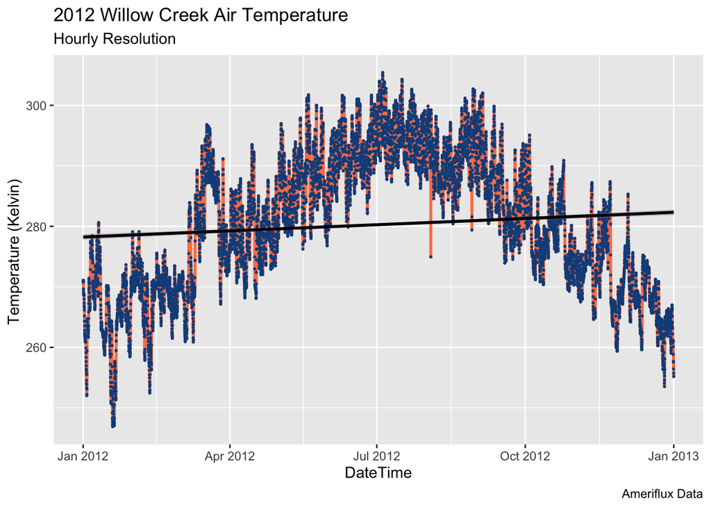

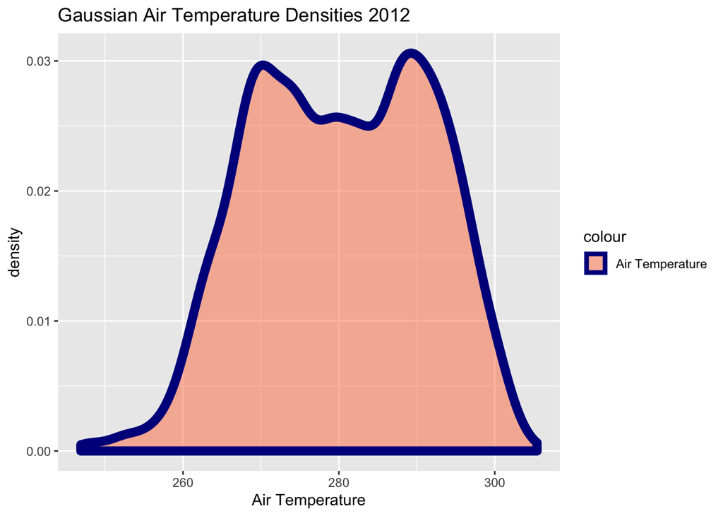

## Extra Credit - 2 Points

Using the WCr_1hr.2010.nc, WCr_1hr.2011.nc and WCr_1hr.2012.nc found in the datasets folder, complete the following

1. Create a density plot using ggplot2 of “Air temperature” with each year being a component of the density plot (adding each year to the density plot as you loop through the data). Adjust alpha settings, colors, linetypes, etc. to make each line extinct.
2. Submit to assignment above labeled ‘extra_credit.png’ - **also submit your code**.